# Optimal Treatment Analysis

## Outcome Variable

**Outcome Variable:** ever_stunted

## Predictor Variables

**Intervention Variable:** perdiar6

**Adjustment Set:**

- arm
- sex
- W_mage
- meducyrs
- W_mhtcm
- W_mwtkg
- W_mbmi
- W_birthwt
- W_birthlen
- W_nrooms
- month
- brthmon
- impfloor
- impsan
- safeh20
- delta_W_mage
- delta_meducyrs
- delta_W_mhtcm
- delta_W_mwtkg
- delta_W_mbmi
- delta_W_birthwt
- delta_W_birthlen
- delta_W_nrooms
- delta_month
- delta_brthmon
- delta_impfloor
- delta_impsan
- delta_safeh20

## Stratifying Variables

The analysis was stratified on these variable(s):

- agecat
- studyid
- country

## Data Summary

| agecat | studyid | country | perdiar6 | ever_stunted | n_cell | n |
| --- | --- | --- | --- | --- | --- | --- |
| 0-24 months (no birth st.) | ki0047075b-MAL-ED | BANGLADESH | (0%, 5%] | 0 | 41 | 217 |
| 0-24 months (no birth st.) | ki0047075b-MAL-ED | BANGLADESH | (0%, 5%] | 1 | 44 | 217 |
| 0-24 months (no birth st.) | ki0047075b-MAL-ED | BANGLADESH | 0% | 0 | 36 | 217 |
| 0-24 months (no birth st.) | ki0047075b-MAL-ED | BANGLADESH | 0% | 1 | 36 | 217 |
| 0-24 months (no birth st.) | ki0047075b-MAL-ED | BANGLADESH | >5% | 0 | 27 | 217 |
| 0-24 months (no birth st.) | ki0047075b-MAL-ED | BANGLADESH | >5% | 1 | 33 | 217 |
| 0-24 months (no birth st.) | ki0047075b-MAL-ED | BRAZIL | (0%, 5%] | 0 | 12 | 208 |
| 0-24 months (no birth st.) | ki0047075b-MAL-ED | BRAZIL | (0%, 5%] | 1 | 2 | 208 |
| 0-24 months (no birth st.) | ki0047075b-MAL-ED | BRAZIL | 0% | 0 | 165 | 208 |
| 0-24 months (no birth st.) | ki0047075b-MAL-ED | BRAZIL | 0% | 1 | 27 | 208 |
| 0-24 months (no birth st.) | ki0047075b-MAL-ED | BRAZIL | >5% | 0 | 2 | 208 |
| 0-24 months (no birth st.) | ki0047075b-MAL-ED | BRAZIL | >5% | 1 | 0 | 208 |
| 0-24 months (no birth st.) | ki0047075b-MAL-ED | INDIA | (0%, 5%] | 0 | 54 | 209 |
| 0-24 months (no birth st.) | ki0047075b-MAL-ED | INDIA | (0%, 5%] | 1 | 52 | 209 |
| 0-24 months (no birth st.) | ki0047075b-MAL-ED | INDIA | 0% | 0 | 24 | 209 |
| 0-24 months (no birth st.) | ki0047075b-MAL-ED | INDIA | 0% | 1 | 25 | 209 |
| 0-24 months (no birth st.) | ki0047075b-MAL-ED | INDIA | >5% | 0 | 23 | 209 |
| 0-24 months (no birth st.) | ki0047075b-MAL-ED | INDIA | >5% | 1 | 31 | 209 |
| 0-24 months (no birth st.) | ki0047075b-MAL-ED | NEPAL | (0%, 5%] | 0 | 54 | 212 |
| 0-24 months (no birth st.) | ki0047075b-MAL-ED | NEPAL | (0%, 5%] | 1 | 14 | 212 |
| 0-24 months (no birth st.) | ki0047075b-MAL-ED | NEPAL | 0% | 0 | 54 | 212 |
| 0-24 months (no birth st.) | ki0047075b-MAL-ED | NEPAL | 0% | 1 | 20 | 212 |
| 0-24 months (no birth st.) | ki0047075b-MAL-ED | NEPAL | >5% | 0 | 49 | 212 |
| 0-24 months (no birth st.) | ki0047075b-MAL-ED | NEPAL | >5% | 1 | 21 | 212 |
| 0-24 months (no birth st.) | ki0047075b-MAL-ED | PERU | (0%, 5%] | 0 | 29 | 266 |
| 0-24 months (no birth st.) | ki0047075b-MAL-ED | PERU | (0%, 5%] | 1 | 51 | 266 |
| 0-24 months (no birth st.) | ki0047075b-MAL-ED | PERU | 0% | 0 | 37 | 266 |
| 0-24 months (no birth st.) | ki0047075b-MAL-ED | PERU | 0% | 1 | 40 | 266 |
| 0-24 months (no birth st.) | ki0047075b-MAL-ED | PERU | >5% | 0 | 49 | 266 |
| 0-24 months (no birth st.) | ki0047075b-MAL-ED | PERU | >5% | 1 | 60 | 266 |

[output cut: 258 more lines]

The following strata were considered:

- agecat: 0-24 months (no birth st.), studyid: ki0047075b-MAL-ED, country: BANGLADESH
- agecat: 0-24 months (no birth st.), studyid: ki0047075b-MAL-ED, country: BRAZIL
- agecat: 0-24 months (no birth st.), studyid: ki0047075b-MAL-ED, country: INDIA
- agecat: 0-24 months (no birth st.), studyid: ki0047075b-MAL-ED, country: NEPAL
- agecat: 0-24 months (no birth st.), studyid: ki0047075b-MAL-ED, country: PERU
- agecat: 0-24 months (no birth st.), studyid: ki0047075b-MAL-ED, country: SOUTH AFRICA
- agecat: 0-24 months (no birth st.), studyid: ki0047075b-MAL-ED, country: TANZANIA, UNITED REPUBLIC OF
- agecat: 0-24 months (no birth st.), studyid: ki1000109-ResPak, country: PAKISTAN
- agecat: 0-24 months (no birth st.), studyid: ki1017093-NIH-Birth, country: BANGLADESH
- agecat: 0-24 months (no birth st.), studyid: ki1017093b-PROVIDE, country: BANGLADESH
- agecat: 0-24 months (no birth st.), studyid: ki1017093c-NIH-Crypto, country: BANGLADESH
- agecat: 0-24 months (no birth st.), studyid: ki1114097-CMIN, country: BANGLADESH
- agecat: 0-24 months (no birth st.), studyid: ki1114097-CMIN, country: BRAZIL
- agecat: 0-24 months (no birth st.), studyid: ki1114097-CMIN, country: GUINEA-BISSAU
- agecat: 0-24 months (no birth st.), studyid: ki1114097-CMIN, country: PERU
- agecat: 0-24 months (no birth st.), studyid: ki1114097-CONTENT, country: PERU
- agecat: 0-6 months (no birth st.), studyid: ki0047075b-MAL-ED, country: BANGLADESH
- agecat: 0-6 months (no birth st.), studyid: ki0047075b-MAL-ED, country: BRAZIL
- agecat: 0-6 months (no birth st.), studyid: ki0047075b-MAL-ED, country: INDIA
- agecat: 0-6 months (no birth st.), studyid: ki0047075b-MAL-ED, country: NEPAL
- agecat: 0-6 months (no birth st.), studyid: ki0047075b-MAL-ED, country: PERU
- agecat: 0-6 months (no birth st.), studyid: ki0047075b-MAL-ED, country: SOUTH AFRICA
- agecat: 0-6 months (no birth st.), studyid: ki0047075b-MAL-ED, country: TANZANIA, UNITED REPUBLIC OF
- agecat: 0-6 months (no birth st.), studyid: ki1000109-ResPak, country: PAKISTAN
- agecat: 0-6 months (no birth st.), studyid: ki1017093-NIH-Birth, country: BANGLADESH
- agecat: 0-6 months (no birth st.), studyid: ki1017093b-PROVIDE, country: BANGLADESH
- agecat: 0-6 months (no birth st.), studyid: ki1017093c-NIH-Crypto, country: BANGLADESH
- agecat: 0-6 months (no birth st.), studyid: ki1114097-CMIN, country: BANGLADESH
- agecat: 0-6 months (no birth st.), studyid: ki1114097-CMIN, country: BRAZIL
- agecat: 0-6 months (no birth st.), studyid: ki1114097-CMIN, country: GUINEA-BISSAU
- agecat: 0-6 months (no birth st.), studyid: ki1114097-CMIN, country: PERU
- agecat: 0-6 months (no birth st.), studyid: ki1114097-CONTENT, country: PERU
- agecat: 6-24 months, studyid: ki0047075b-MAL-ED, country: BANGLADESH
- agecat: 6-24 months, studyid: ki0047075b-MAL-ED, country: BRAZIL
- agecat: 6-24 months, studyid: ki0047075b-MAL-ED, country: INDIA
- agecat: 6-24 months, studyid: ki0047075b-MAL-ED, country: NEPAL
- agecat: 6-24 months, studyid: ki0047075b-MAL-ED, country: PERU
- agecat: 6-24 months, studyid: ki0047075b-MAL-ED, country: SOUTH AFRICA
- agecat: 6-24 months, studyid: ki0047075b-MAL-ED, country: TANZANIA, UNITED REPUBLIC OF
- agecat: 6-24 months, studyid: ki1000109-ResPak, country: PAKISTAN
- agecat: 6-24 months, studyid: ki1017093-NIH-Birth, country: BANGLADESH
- agecat: 6-24 months, studyid: ki1017093b-PROVIDE, country: BANGLADESH
- agecat: 6-24 months, studyid: ki1017093c-NIH-Crypto, country: BANGLADESH
- agecat: 6-24 months, studyid: ki1114097-CMIN, country: BANGLADESH
- agecat: 6-24 months, studyid: ki1114097-CMIN, country: BRAZIL
- agecat: 6-24 months, studyid: ki1114097-CMIN, country: GUINEA-BISSAU
- agecat: 6-24 months, studyid: ki1114097-CMIN, country: PERU
- agecat: 6-24 months, studyid: ki1114097-CONTENT, country: PERU

### Dropped Strata

Some strata were dropped due to rare outcomes:

- agecat: 0-24 months (no birth st.), studyid: ki0047075b-MAL-ED, country: BRAZIL
- agecat: 0-24 months (no birth st.), studyid: ki0047075b-MAL-ED, country: SOUTH AFRICA
- agecat: 0-6 months (no birth st.), studyid: ki0047075b-MAL-ED, country: BRAZIL
- agecat: 0-6 months (no birth st.), studyid: ki0047075b-MAL-ED, country: NEPAL
- agecat: 0-6 months (no birth st.), studyid: ki0047075b-MAL-ED, country: SOUTH AFRICA
- agecat: 0-6 months (no birth st.), studyid: ki1114097-CMIN, country: BRAZIL
- agecat: 0-6 months (no birth st.), studyid: ki1114097-CMIN, country: GUINEA-BISSAU
- agecat: 0-6 months (no birth st.), studyid: ki1114097-CONTENT, country: PERU
- agecat: 6-24 months, studyid: ki0047075b-MAL-ED, country: BRAZIL
- agecat: 6-24 months, studyid: ki0047075b-MAL-ED, country: SOUTH AFRICA
- agecat: 6-24 months, studyid: ki1000109-ResPak, country: PAKISTAN
- agecat: 6-24 months, studyid: ki1114097-CONTENT, country: PERU

## Methods Detail

We’re interested in the causal parameters $E[Y_a]$ for all values of $a \in \mathcal{A}$. These parameters represent the mean outcome if, possibly contrary to fact, we intervened to set all units to have $A=a$. Under the randomization and positivity assumptions, these are identified by the statistical parameters $\psi_a=E_W[E_{Y|A,W}(Y|A=a,W)]$. In addition, we’re interested in the mean of $Y$, $E[Y]$ under no intervention (the observed mean). We will estimate these parameters by using SuperLearner to fit the relevant likelihood factors – $E_{Y|A,W}(Y|A=a,W)$ and $p(A=a|W)$, and then updating our likelihood fit using a joint TMLE.

For unadjusted analyses ($W=\{\}$), initial likelihoods were estimated using Lrnr_glm to estimate the simple $E(Y|A)$ and Lrnr_mean to estimate $p(A)$. For adjusted analyses, a small library containing Lrnr_glmnet, Lrnr_xgboost, and Lrnr_mean was used.

Having estimated these parameters, we will then use the delta method to estimate relative risks and attributable risks relative to a prespecified baseline level of $A$.

# Results Detail

## Results Plots

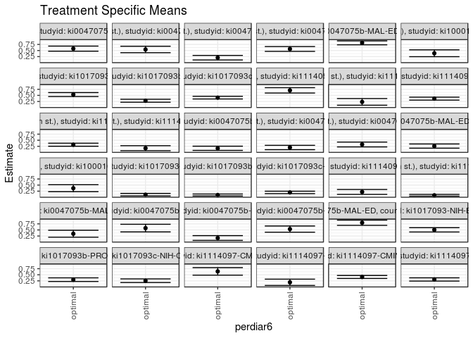

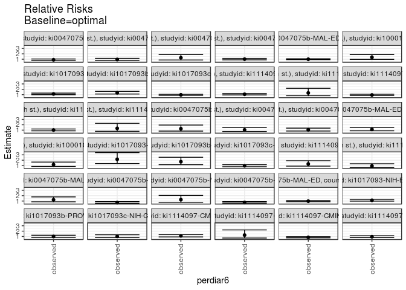

## Results Table

### Parameter: TSM

| agecat | studyid | country | intervention_level | baseline_level | estimate | ci_lower | ci_upper |
| --- | --- | --- | --- | --- | --- | --- | --- |
| 0-24 months (no birth st.) | ki0047075b-MAL-ED | BANGLADESH | optimal | NA | 0.5774804 | 0.4731435 | 0.6818173 |
| 0-24 months (no birth st.) | ki0047075b-MAL-ED | INDIA | optimal | NA | 0.5433849 | 0.4104696 | 0.6763001 |
| 0-24 months (no birth st.) | ki0047075b-MAL-ED | NEPAL | optimal | NA | 0.2051436 | 0.1117109 | 0.2985762 |
| 0-24 months (no birth st.) | ki0047075b-MAL-ED | PERU | optimal | NA | 0.5641461 | 0.4641106 | 0.6641816 |
| 0-24 months (no birth st.) | ki0047075b-MAL-ED | TANZANIA, UNITED REPUBLIC OF | optimal | NA | 0.8159252 | 0.7353124 | 0.8965380 |
| 0-24 months (no birth st.) | ki1000109-ResPak | PAKISTAN | optimal | NA | 0.3872623 | 0.2460087 | 0.5285159 |
| 0-24 months (no birth st.) | ki1017093-NIH-Birth | BANGLADESH | optimal | NA | 0.5335871 | 0.4520489 | 0.6151253 |
| 0-24 months (no birth st.) | ki1017093b-PROVIDE | BANGLADESH | optimal | NA | 0.2787302 | 0.2177887 | 0.3396718 |
| 0-24 months (no birth st.) | ki1017093c-NIH-Crypto | BANGLADESH | optimal | NA | 0.4066264 | 0.3517520 | 0.4615007 |
| 0-24 months (no birth st.) | ki1114097-CMIN | BANGLADESH | optimal | NA | 0.7065449 | 0.5966144 | 0.8164755 |
| 0-24 months (no birth st.) | ki1114097-CMIN | BRAZIL | optimal | NA | 0.2317537 | 0.0948837 | 0.3686238 |
| 0-24 months (no birth st.) | ki1114097-CMIN | GUINEA-BISSAU | optimal | NA | 0.3657912 | 0.3051681 | 0.4264142 |
| 0-24 months (no birth st.) | ki1114097-CMIN | PERU | optimal | NA | 0.3153816 | 0.2527138 | 0.3780494 |
| 0-24 months (no birth st.) | ki1114097-CONTENT | PERU | optimal | NA | 0.1720625 | 0.0688176 | 0.2753074 |
| 0-6 months (no birth st.) | ki0047075b-MAL-ED | BANGLADESH | optimal | NA | 0.1681140 | 0.0816022 | 0.2546258 |
| 0-6 months (no birth st.) | ki0047075b-MAL-ED | INDIA | optimal | NA | 0.2013029 | 0.1117473 | 0.2908586 |
| 0-6 months (no birth st.) | ki0047075b-MAL-ED | PERU | optimal | NA | 0.3244472 | 0.2247548 | 0.4241396 |
| 0-6 months (no birth st.) | ki0047075b-MAL-ED | TANZANIA, UNITED REPUBLIC OF | optimal | NA | 0.2598270 | 0.1736837 | 0.3459703 |
| 0-6 months (no birth st.) | ki1000109-ResPak | PAKISTAN | optimal | NA | 0.3718145 | 0.2284635 | 0.5151655 |
| 0-6 months (no birth st.) | ki1017093-NIH-Birth | BANGLADESH | optimal | NA | 0.1055924 | 0.0541344 | 0.1570505 |
| 0-6 months (no birth st.) | ki1017093b-PROVIDE | BANGLADESH | optimal | NA | 0.0923218 | 0.0521265 | 0.1325171 |
| 0-6 months (no birth st.) | ki1017093c-NIH-Crypto | BANGLADESH | optimal | NA | 0.1982367 | 0.1481884 | 0.2482850 |
| 0-6 months (no birth st.) | ki1114097-CMIN | BANGLADESH | optimal | NA | 0.2180847 | 0.1175501 | 0.3186193 |
| 0-6 months (no birth st.) | ki1114097-CMIN | PERU | optimal | NA | 0.0807269 | 0.0435322 | 0.1179215 |
| 6-24 months | ki0047075b-MAL-ED | BANGLADESH | optimal | NA | 0.3424476 | 0.1988671 | 0.4860280 |
| 6-24 months | ki0047075b-MAL-ED | INDIA | optimal | NA | 0.5753218 | 0.4187884 | 0.7318552 |
| 6-24 months | ki0047075b-MAL-ED | NEPAL | optimal | NA | 0.1677158 | 0.0694806 | 0.2659510 |
| 6-24 months | ki0047075b-MAL-ED | PERU | optimal | NA | 0.5341927 | 0.4064117 | 0.6619736 |
| 6-24 months | ki0047075b-MAL-ED | TANZANIA, UNITED REPUBLIC OF | optimal | NA | 0.7964346 | 0.6884949 | 0.9043743 |
| 6-24 months | ki1017093-NIH-Birth | BANGLADESH | optimal | NA | 0.5041672 | 0.4157495 | 0.5925849 |
| 6-24 months | ki1017093b-PROVIDE | BANGLADESH | optimal | NA | 0.2988136 | 0.2238170 | 0.3738101 |
| 6-24 months | ki1017093c-NIH-Crypto | BANGLADESH | optimal | NA | 0.2552621 | 0.1813514 | 0.3291727 |
| 6-24 months | ki1114097-CMIN | BANGLADESH | optimal | NA | 0.6391495 | 0.4843046 | 0.7939944 |
| 6-24 months | ki1114097-CMIN | BRAZIL | optimal | NA | 0.1905667 | 0.0616731 | 0.3194603 |
| 6-24 months | ki1114097-CMIN | GUINEA-BISSAU | optimal | NA | 0.4103405 | 0.3491725 | 0.4715085 |
| 6-24 months | ki1114097-CMIN | PERU | optimal | NA | 0.3077840 | 0.2403689 | 0.3751990 |

### Parameter: E(Y)

| agecat | studyid | country | intervention_level | baseline_level | estimate | ci_lower | ci_upper |
| --- | --- | --- | --- | --- | --- | --- | --- |
| 0-24 months (no birth st.) | ki0047075b-MAL-ED | BANGLADESH | observed | NA | 0.5207373 | 0.4541154 | 0.5873593 |
| 0-24 months (no birth st.) | ki0047075b-MAL-ED | INDIA | observed | NA | 0.5167464 | 0.4488350 | 0.5846578 |
| 0-24 months (no birth st.) | ki0047075b-MAL-ED | NEPAL | observed | NA | 0.2594340 | 0.2002911 | 0.3185768 |
| 0-24 months (no birth st.) | ki0047075b-MAL-ED | PERU | observed | NA | 0.5676692 | 0.5080232 | 0.6273151 |
| 0-24 months (no birth st.) | ki0047075b-MAL-ED | TANZANIA, UNITED REPUBLIC OF | observed | NA | 0.8127854 | 0.7610035 | 0.8645672 |
| 0-24 months (no birth st.) | ki1000109-ResPak | PAKISTAN | observed | NA | 0.5223881 | 0.4531624 | 0.5916138 |
| 0-24 months (no birth st.) | ki1017093-NIH-Birth | BANGLADESH | observed | NA | 0.6041667 | 0.5624147 | 0.6459187 |
| 0-24 months (no birth st.) | ki1017093b-PROVIDE | BANGLADESH | observed | NA | 0.3753943 | 0.3376725 | 0.4131162 |
| 0-24 months (no birth st.) | ki1017093c-NIH-Crypto | BANGLADESH | observed | NA | 0.3935681 | 0.3560687 | 0.4310676 |
| 0-24 months (no birth st.) | ki1114097-CMIN | BANGLADESH | observed | NA | 0.7559524 | 0.6908084 | 0.8210964 |
| 0-24 months (no birth st.) | ki1114097-CMIN | BRAZIL | observed | NA | 0.3070175 | 0.2219720 | 0.3920631 |
| 0-24 months (no birth st.) | ki1114097-CMIN | GUINEA-BISSAU | observed | NA | 0.3443038 | 0.3111501 | 0.3774575 |
| 0-24 months (no birth st.) | ki1114097-CMIN | PERU | observed | NA | 0.3229167 | 0.2875370 | 0.3582963 |
| 0-24 months (no birth st.) | ki1114097-CONTENT | PERU | observed | NA | 0.2284264 | 0.1696529 | 0.2871999 |
| 0-6 months (no birth st.) | ki0047075b-MAL-ED | BANGLADESH | observed | NA | 0.2119816 | 0.1574763 | 0.2664868 |
| 0-6 months (no birth st.) | ki0047075b-MAL-ED | INDIA | observed | NA | 0.2105263 | 0.1551227 | 0.2659300 |
| 0-6 months (no birth st.) | ki0047075b-MAL-ED | PERU | observed | NA | 0.3458647 | 0.2885967 | 0.4031327 |
| 0-6 months (no birth st.) | ki0047075b-MAL-ED | TANZANIA, UNITED REPUBLIC OF | observed | NA | 0.2968037 | 0.2361590 | 0.3574483 |
| 0-6 months (no birth st.) | ki1000109-ResPak | PAKISTAN | observed | NA | 0.4378109 | 0.3690538 | 0.5065681 |
| 0-6 months (no birth st.) | ki1017093-NIH-Birth | BANGLADESH | observed | NA | 0.2291667 | 0.1932828 | 0.2650505 |
| 0-6 months (no birth st.) | ki1017093b-PROVIDE | BANGLADESH | observed | NA | 0.1593060 | 0.1307970 | 0.1878149 |
| 0-6 months (no birth st.) | ki1017093c-NIH-Crypto | BANGLADESH | observed | NA | 0.1898928 | 0.1597870 | 0.2199986 |
| 0-6 months (no birth st.) | ki1114097-CMIN | BANGLADESH | observed | NA | 0.2857143 | 0.2171983 | 0.3542303 |
| 0-6 months (no birth st.) | ki1114097-CMIN | PERU | observed | NA | 0.0744681 | 0.0543935 | 0.0945427 |
| 6-24 months | ki0047075b-MAL-ED | BANGLADESH | observed | NA | 0.4213836 | 0.3443902 | 0.4983771 |
| 6-24 months | ki0047075b-MAL-ED | INDIA | observed | NA | 0.4129032 | 0.3351414 | 0.4906651 |
| 6-24 months | ki0047075b-MAL-ED | NEPAL | observed | NA | 0.2102564 | 0.1529155 | 0.2675974 |
| 6-24 months | ki0047075b-MAL-ED | PERU | observed | NA | 0.3959732 | 0.3171819 | 0.4747644 |
| 6-24 months | ki0047075b-MAL-ED | TANZANIA, UNITED REPUBLIC OF | observed | NA | 0.7793103 | 0.7115754 | 0.8470453 |
| 6-24 months | ki1017093-NIH-Birth | BANGLADESH | observed | NA | 0.5739130 | 0.5216565 | 0.6261696 |
| 6-24 months | ki1017093b-PROVIDE | BANGLADESH | observed | NA | 0.2997812 | 0.2577294 | 0.3418330 |
| 6-24 months | ki1017093c-NIH-Crypto | BANGLADESH | observed | NA | 0.2628458 | 0.2244546 | 0.3012371 |
| 6-24 months | ki1114097-CMIN | BANGLADESH | observed | NA | 0.7117117 | 0.6270636 | 0.7963598 |
| 6-24 months | ki1114097-CMIN | BRAZIL | observed | NA | 0.2403846 | 0.1578607 | 0.3229085 |
| 6-24 months | ki1114097-CMIN | GUINEA-BISSAU | observed | NA | 0.3467532 | 0.3131150 | 0.3803915 |
| 6-24 months | ki1114097-CMIN | PERU | observed | NA | 0.2940171 | 0.2570662 | 0.3309680 |

### Parameter: RR

| agecat | studyid | country | intervention_level | baseline_level | estimate | ci_lower | ci_upper |
| --- | --- | --- | --- | --- | --- | --- | --- |
| 0-24 months (no birth st.) | ki0047075b-MAL-ED | BANGLADESH | observed | optimal | 0.9017402 | 0.7798252 | 1.0427150 |
| 0-24 months (no birth st.) | ki0047075b-MAL-ED | INDIA | observed | optimal | 0.9509768 | 0.7811982 | 1.1576537 |
| 0-24 months (no birth st.) | ki0047075b-MAL-ED | NEPAL | observed | optimal | 1.2646459 | 0.8534527 | 1.8739518 |
| 0-24 months (no birth st.) | ki0047075b-MAL-ED | PERU | observed | optimal | 1.0062450 | 0.8787442 | 1.1522455 |
| 0-24 months (no birth st.) | ki0047075b-MAL-ED | TANZANIA, UNITED REPUBLIC OF | observed | optimal | 0.9961518 | 0.9249596 | 1.0728236 |
| 0-24 months (no birth st.) | ki1000109-ResPak | PAKISTAN | observed | optimal | 1.3489256 | 0.9755005 | 1.8652991 |
| 0-24 months (no birth st.) | ki1017093-NIH-Birth | BANGLADESH | observed | optimal | 1.1322738 | 0.9956939 | 1.2875883 |
| 0-24 months (no birth st.) | ki1017093b-PROVIDE | BANGLADESH | observed | optimal | 1.3468017 | 1.1218814 | 1.6168150 |
| 0-24 months (no birth st.) | ki1017093c-NIH-Crypto | BANGLADESH | observed | optimal | 0.9678865 | 0.8796728 | 1.0649462 |
| 0-24 months (no birth st.) | ki1114097-CMIN | BANGLADESH | observed | optimal | 1.0699283 | 0.9523382 | 1.2020378 |
| 0-24 months (no birth st.) | ki1114097-CMIN | BRAZIL | observed | optimal | 1.3247577 | 0.8021605 | 2.1878202 |
| 0-24 months (no birth st.) | ki1114097-CMIN | GUINEA-BISSAU | observed | optimal | 0.9412578 | 0.8197483 | 1.0807784 |
| 0-24 months (no birth st.) | ki1114097-CMIN | PERU | observed | optimal | 1.0238920 | 0.8672317 | 1.2088519 |
| 0-24 months (no birth st.) | ki1114097-CONTENT | PERU | observed | optimal | 1.3275781 | 0.7794984 | 2.2610226 |
| 0-6 months (no birth st.) | ki0047075b-MAL-ED | BANGLADESH | observed | optimal | 1.2609395 | 0.8171730 | 1.9456938 |
| 0-6 months (no birth st.) | ki0047075b-MAL-ED | INDIA | observed | optimal | 1.0458185 | 0.7448061 | 1.4684846 |
| 0-6 months (no birth st.) | ki0047075b-MAL-ED | PERU | observed | optimal | 1.0660121 | 0.8277447 | 1.3728649 |
| 0-6 months (no birth st.) | ki0047075b-MAL-ED | TANZANIA, UNITED REPUBLIC OF | observed | optimal | 1.1423125 | 0.8753794 | 1.4906426 |
| 0-6 months (no birth st.) | ki1000109-ResPak | PAKISTAN | observed | optimal | 1.1774983 | 0.8376677 | 1.6551936 |
| 0-6 months (no birth st.) | ki1017093-NIH-Birth | BANGLADESH | observed | optimal | 2.1702944 | 1.3811521 | 3.4103253 |
| 0-6 months (no birth st.) | ki1017093b-PROVIDE | BANGLADESH | observed | optimal | 1.7255511 | 1.1685856 | 2.5479747 |
| 0-6 months (no birth st.) | ki1017093c-NIH-Crypto | BANGLADESH | observed | optimal | 0.9579094 | 0.7856637 | 1.1679175 |
| 0-6 months (no birth st.) | ki1114097-CMIN | BANGLADESH | observed | optimal | 1.3101070 | 0.9008381 | 1.9053149 |
| 0-6 months (no birth st.) | ki1114097-CMIN | PERU | observed | optimal | 0.9224697 | 0.6335508 | 1.3431448 |
| 6-24 months | ki0047075b-MAL-ED | BANGLADESH | observed | optimal | 1.2305056 | 0.8542048 | 1.7725773 |
| 6-24 months | ki0047075b-MAL-ED | INDIA | observed | optimal | 0.7176909 | 0.5776020 | 0.8917562 |
| 6-24 months | ki0047075b-MAL-ED | NEPAL | observed | optimal | 1.2536468 | 0.7671821 | 2.0485754 |
| 6-24 months | ki0047075b-MAL-ED | PERU | observed | optimal | 0.7412553 | 0.6164881 | 0.8912735 |
| 6-24 months | ki0047075b-MAL-ED | TANZANIA, UNITED REPUBLIC OF | observed | optimal | 0.9784988 | 0.8794562 | 1.0886955 |
| 6-24 months | ki1017093-NIH-Birth | BANGLADESH | observed | optimal | 1.1383387 | 0.9855135 | 1.3148626 |
| 6-24 months | ki1017093b-PROVIDE | BANGLADESH | observed | optimal | 1.0032382 | 0.8151797 | 1.2346810 |
| 6-24 months | ki1017093c-NIH-Crypto | BANGLADESH | observed | optimal | 1.0297098 | 0.8002707 | 1.3249296 |
| 6-24 months | ki1114097-CMIN | BANGLADESH | observed | optimal | 1.1135293 | 0.9191642 | 1.3489946 |
| 6-24 months | ki1114097-CMIN | BRAZIL | observed | optimal | 1.2614199 | 0.7145920 | 2.2266973 |
| 6-24 months | ki1114097-CMIN | GUINEA-BISSAU | observed | optimal | 0.8450378 | 0.7470997 | 0.9558147 |
| 6-24 months | ki1114097-CMIN | PERU | observed | optimal | 0.9552709 | 0.7962700 | 1.1460215 |

### Parameter: PAR

| agecat | studyid | country | intervention_level | baseline_level | estimate | ci_lower | ci_upper |
| --- | --- | --- | --- | --- | --- | --- | --- |
| 0-24 months (no birth st.) | ki0047075b-MAL-ED | BANGLADESH | optimal | NA | -0.0567431 | -0.1399956 | 0.0265094 |
| 0-24 months (no birth st.) | ki0047075b-MAL-ED | INDIA | optimal | NA | -0.0266384 | -0.1338210 | 0.0805441 |
| 0-24 months (no birth st.) | ki0047075b-MAL-ED | NEPAL | optimal | NA | 0.0542904 | -0.0272721 | 0.1358529 |
| 0-24 months (no birth st.) | ki0047075b-MAL-ED | PERU | optimal | NA | 0.0035231 | -0.0728857 | 0.0799319 |
| 0-24 months (no birth st.) | ki0047075b-MAL-ED | TANZANIA, UNITED REPUBLIC OF | optimal | NA | -0.0031398 | -0.0636450 | 0.0573654 |
| 0-24 months (no birth st.) | ki1000109-ResPak | PAKISTAN | optimal | NA | 0.1351257 | 0.0105094 | 0.2597420 |
| 0-24 months (no birth st.) | ki1017093-NIH-Birth | BANGLADESH | optimal | NA | 0.0705796 | 0.0023817 | 0.1387774 |
| 0-24 months (no birth st.) | ki1017093b-PROVIDE | BANGLADESH | optimal | NA | 0.0966641 | 0.0459492 | 0.1473790 |
| 0-24 months (no birth st.) | ki1017093c-NIH-Crypto | BANGLADESH | optimal | NA | -0.0130582 | -0.0519373 | 0.0258209 |
| 0-24 months (no birth st.) | ki1114097-CMIN | BANGLADESH | optimal | NA | 0.0494075 | -0.0322767 | 0.1310917 |
| 0-24 months (no birth st.) | ki1114097-CMIN | BRAZIL | optimal | NA | 0.0752638 | -0.0413416 | 0.1918692 |
| 0-24 months (no birth st.) | ki1114097-CMIN | GUINEA-BISSAU | optimal | NA | -0.0214874 | -0.0720185 | 0.0290438 |
| 0-24 months (no birth st.) | ki1114097-CMIN | PERU | optimal | NA | 0.0075351 | -0.0448459 | 0.0599161 |
| 0-24 months (no birth st.) | ki1114097-CONTENT | PERU | optimal | NA | 0.0563639 | -0.0358515 | 0.1485793 |
| 0-6 months (no birth st.) | ki0047075b-MAL-ED | BANGLADESH | optimal | NA | 0.0438676 | -0.0293916 | 0.1171268 |
| 0-6 months (no birth st.) | ki0047075b-MAL-ED | INDIA | optimal | NA | 0.0092234 | -0.0589654 | 0.0774121 |
| 0-6 months (no birth st.) | ki0047075b-MAL-ED | PERU | optimal | NA | 0.0214174 | -0.0606092 | 0.1034441 |
| 0-6 months (no birth st.) | ki0047075b-MAL-ED | TANZANIA, UNITED REPUBLIC OF | optimal | NA | 0.0369766 | -0.0327724 | 0.1067257 |
| 0-6 months (no birth st.) | ki1000109-ResPak | PAKISTAN | optimal | NA | 0.0659964 | -0.0602623 | 0.1922552 |
| 0-6 months (no birth st.) | ki1017093-NIH-Birth | BANGLADESH | optimal | NA | 0.1235742 | 0.0731949 | 0.1739536 |
| 0-6 months (no birth st.) | ki1017093b-PROVIDE | BANGLADESH | optimal | NA | 0.0669842 | 0.0295188 | 0.1044496 |
| 0-6 months (no birth st.) | ki1017093c-NIH-Crypto | BANGLADESH | optimal | NA | -0.0083439 | -0.0476470 | 0.0309592 |
| 0-6 months (no birth st.) | ki1114097-CMIN | BANGLADESH | optimal | NA | 0.0676296 | -0.0143317 | 0.1495909 |
| 0-6 months (no birth st.) | ki1114097-CMIN | PERU | optimal | NA | -0.0062588 | -0.0366231 | 0.0241055 |
| 6-24 months | ki0047075b-MAL-ED | BANGLADESH | optimal | NA | 0.0789361 | -0.0459003 | 0.2037724 |
| 6-24 months | ki0047075b-MAL-ED | INDIA | optimal | NA | -0.1624186 | -0.2878806 | -0.0369566 |
| 6-24 months | ki0047075b-MAL-ED | NEPAL | optimal | NA | 0.0425406 | -0.0394465 | 0.1245277 |
| 6-24 months | ki0047075b-MAL-ED | PERU | optimal | NA | -0.1382195 | -0.2343603 | -0.0420787 |
| 6-24 months | ki0047075b-MAL-ED | TANZANIA, UNITED REPUBLIC OF | optimal | NA | -0.0171243 | -0.1020833 | 0.0678348 |
| 6-24 months | ki1017093-NIH-Birth | BANGLADESH | optimal | NA | 0.0697458 | -0.0028064 | 0.1422981 |
| 6-24 months | ki1017093b-PROVIDE | BANGLADESH | optimal | NA | 0.0009676 | -0.0610596 | 0.0629949 |
| 6-24 months | ki1017093c-NIH-Crypto | BANGLADESH | optimal | NA | 0.0075838 | -0.0567884 | 0.0719560 |
| 6-24 months | ki1114097-CMIN | BANGLADESH | optimal | NA | 0.0725622 | -0.0488749 | 0.1939993 |
| 6-24 months | ki1114097-CMIN | BRAZIL | optimal | NA | 0.0498179 | -0.0590952 | 0.1587311 |
| 6-24 months | ki1114097-CMIN | GUINEA-BISSAU | optimal | NA | -0.0635873 | -0.1138999 | -0.0132747 |
| 6-24 months | ki1114097-CMIN | PERU | optimal | NA | -0.0137669 | -0.0697913 | 0.0422575 |

### Parameter: PAF

| agecat | studyid | country | intervention_level | baseline_level | estimate | ci_lower | ci_upper |
| --- | --- | --- | --- | --- | --- | --- | --- |
| 0-24 months (no birth st.) | ki0047075b-MAL-ED | BANGLADESH | optimal | NA | -0.1089668 | -0.2823386 | 0.0409651 |
| 0-24 months (no birth st.) | ki0047075b-MAL-ED | INDIA | optimal | NA | -0.0515503 | -0.2800850 | 0.1361838 |
| 0-24 months (no birth st.) | ki0047075b-MAL-ED | NEPAL | optimal | NA | 0.2092648 | -0.1717111 | 0.4663683 |
| 0-24 months (no birth st.) | ki0047075b-MAL-ED | PERU | optimal | NA | 0.0062062 | -0.1379877 | 0.1321294 |
| 0-24 months (no birth st.) | ki0047075b-MAL-ED | TANZANIA, UNITED REPUBLIC OF | optimal | NA | -0.0038630 | -0.0811283 | 0.0678803 |
| 0-24 months (no birth st.) | ki1000109-ResPak | PAKISTAN | optimal | NA | 0.2586693 | -0.0251148 | 0.4638930 |
| 0-24 months (no birth st.) | ki1017093-NIH-Birth | BANGLADESH | optimal | NA | 0.1168214 | -0.0043247 | 0.2233543 |
| 0-24 months (no birth st.) | ki1017093b-PROVIDE | BANGLADESH | optimal | NA | 0.2575002 | 0.1086402 | 0.3815001 |
| 0-24 months (no birth st.) | ki1017093c-NIH-Crypto | BANGLADESH | optimal | NA | -0.0331790 | -0.1367863 | 0.0609854 |
| 0-24 months (no birth st.) | ki1114097-CMIN | BANGLADESH | optimal | NA | 0.0653579 | -0.0500471 | 0.1680794 |
| 0-24 months (no birth st.) | ki1114097-CMIN | BRAZIL | optimal | NA | 0.2451450 | -0.2466333 | 0.5429240 |
| 0-24 months (no birth st.) | ki1114097-CMIN | GUINEA-BISSAU | optimal | NA | -0.0624082 | -0.2198866 | 0.0747410 |
| 0-24 months (no birth st.) | ki1114097-CMIN | PERU | optimal | NA | 0.0233345 | -0.1530943 | 0.1727688 |
| 0-24 months (no birth st.) | ki1114097-CONTENT | PERU | optimal | NA | 0.2467486 | -0.2828763 | 0.5577223 |
| 0-6 months (no birth st.) | ki0047075b-MAL-ED | BANGLADESH | optimal | NA | 0.2069406 | -0.2237310 | 0.4860445 |
| 0-6 months (no birth st.) | ki0047075b-MAL-ED | INDIA | optimal | NA | 0.0438111 | -0.3426314 | 0.3190259 |
| 0-6 months (no birth st.) | ki0047075b-MAL-ED | PERU | optimal | NA | 0.0619243 | -0.2081019 | 0.2715962 |
| 0-6 months (no birth st.) | ki0047075b-MAL-ED | TANZANIA, UNITED REPUBLIC OF | optimal | NA | 0.1245828 | -0.1423618 | 0.3291484 |
| 0-6 months (no birth st.) | ki1000109-ResPak | PAKISTAN | optimal | NA | 0.1507418 | -0.1937908 | 0.3958411 |
| 0-6 months (no birth st.) | ki1017093-NIH-Birth | BANGLADESH | optimal | NA | 0.5392330 | 0.2759668 | 0.7067728 |
| 0-6 months (no birth st.) | ki1017093b-PROVIDE | BANGLADESH | optimal | NA | 0.4204750 | 0.1442647 | 0.6075314 |
| 0-6 months (no birth st.) | ki1017093c-NIH-Crypto | BANGLADESH | optimal | NA | -0.0439401 | -0.2728092 | 0.1437751 |
| 0-6 months (no birth st.) | ki1114097-CMIN | BANGLADESH | optimal | NA | 0.2367035 | -0.1100774 | 0.4751524 |
| 0-6 months (no birth st.) | ki1114097-CMIN | PERU | optimal | NA | -0.0840464 | -0.5784055 | 0.2554786 |
| 6-24 months | ki0047075b-MAL-ED | BANGLADESH | optimal | NA | 0.1873259 | -0.1706794 | 0.4358497 |
| 6-24 months | ki0047075b-MAL-ED | INDIA | optimal | NA | -0.3933575 | -0.7312959 | -0.1213827 |
| 6-24 months | ki0047075b-MAL-ED | NEPAL | optimal | NA | 0.2023272 | -0.3034716 | 0.5118559 |
| 6-24 months | ki0047075b-MAL-ED | PERU | optimal | NA | -0.3490628 | -0.6220914 | -0.1219901 |
| 6-24 months | ki0047075b-MAL-ED | TANZANIA, UNITED REPUBLIC OF | optimal | NA | -0.0219736 | -0.1370663 | 0.0814695 |
| 6-24 months | ki1017093-NIH-Birth | BANGLADESH | optimal | NA | 0.1215268 | -0.0146994 | 0.2394643 |
| 6-24 months | ki1017093b-PROVIDE | BANGLADESH | optimal | NA | 0.0032278 | -0.2267233 | 0.1900742 |
| 6-24 months | ki1017093c-NIH-Crypto | BANGLADESH | optimal | NA | 0.0288526 | -0.2495772 | 0.2452429 |
| 6-24 months | ki1114097-CMIN | BANGLADESH | optimal | NA | 0.1019545 | -0.0879449 | 0.2587072 |
| 6-24 months | ki1114097-CMIN | BRAZIL | optimal | NA | 0.2072426 | -0.3993999 | 0.5509044 |
| 6-24 months | ki1114097-CMIN | GUINEA-BISSAU | optimal | NA | -0.1833790 | -0.3385095 | -0.0462279 |
| 6-24 months | ki1114097-CMIN | PERU | optimal | NA | -0.0468234 | -0.2558555 | 0.1274160 |